# Practical session 2: Bandits

# Fixing the setting for the rest of the practical session

Let's define a dose finding study with three doses ($K = 3$) where you need to choose from with `actual_toxicity_prob=[0.1, 0.35, 0.8]` and targeted toxicity probability is $\theta = 0.3$.

```python
###Problem definition
bandit = Bandit(n_arm=3, n_pulls=2000, actual_toxicity_prob=[0.1, 0.35, 0.8], theta=0.3)
```

### Q1.b: $\epsilon$-greedy for k-armed bandit and Optimistic initial values

#### Q1.b1: $\epsilon$-greedy algorithm implementation

Implement the $\epsilon$-greedy method.

```python
def eps_greedy(
    bandit: Bandit,
    eps: float,
    init_q: float = .0
    ) -> Tuple[list, list, list]:
  """
  .inputs:
    bandit: A bandit problem, instantiated from the above class.
    eps: The epsilon value.
    init_q: Initial estimation of each arm's value.
  .outputs:
    rew_record: The record of rewards at each timestep.
    avg_ret_record: The average of rewards up to step t, where t goes from 0 to n_pulls. For example: If
    we define `ret_T` = \sum^T_{t=0}{r_t}, `avg_ret_record` = ret_T / (1+T).
    tot_reg_record: The  regret up to step t, where t goes from 0 to n_pulls.
    opt_action_perc_record: Percentage of optimal arm selected.
  """
  # initialize q values
  q = np.array([init_q]*bandit.n_arm, dtype=float)

  ret = .0
  rew_record = []
  avg_ret_record = []
  tot_reg_record = []
  opt_action_perc_record = []

  for t in range(bandit.n_pulls):
    # ----------------------------------------------
    ...
    # ----------------------------------------------

  return rew_record, avg_ret_record, tot_reg_record, opt_action_perc_record
```

```python
### Solution
def eps_greedy(bandit, eps):
    """
    Perform epsilon-greedy strategy on the given bandit.
    .inputs:
      bandit: Bandit object
      eps: Epsilon value for exploration
    .outputs:
      rew_rec: list of rewards at each step
      avg_ret_rec: list of average returns at each step
      tot_reg_rec: list of cumulative regrets at each step
      opt_act_rec: list of percentage optimal actions at each step
    """
    rew_rec = []
    avg_ret_rec = []
    tot_reg_rec = []
    opt_act_rec = []

    n_pulls = bandit.n_pulls
    # Convert actual toxicity probabilities to a NumPy array for numerical operations
    actual_toxicity_prob = np.array(bandit.actual_toxicity_prob)
    opt_arm = np.argmin(np.abs(actual_toxicity_prob - bandit.theta))

    cumulative_reward = 0
    optimal_action_count = 0
    cumulative_regret = 0

    # Initialize estimated probabilities and counts
    estimated_probs = np.zeros(bandit.n_arm)

    for t in range(n_pulls):
        # Exploration vs Exploitation
        if np.random.rand() < eps:  # Exploration
            arm = np.random.randint(0, bandit.n_arm)
        else:  # Exploitation
            arm = np.argmin(np.abs(estimated_probs - bandit.theta))

        # Pull the arm and get the reward
        reward = bandit.pull(arm)

        # Update cumulative reward and regret
        cumulative_reward += reward
        if arm == opt_arm:
            optimal_action_count += 1

        regret = abs(bandit.theta - actual_toxicity_prob[opt_arm]) - abs(bandit.theta - actual_toxicity_prob[arm])
        cumulative_regret += regret

        # Update estimated probabilities using running average
        if bandit.num_dose_selected[arm] > 0:
            estimated_probs[arm] = bandit.num_toxic[arm] / bandit.num_dose_selected[arm]

        # Record metrics
        rew_rec.append(reward)
        avg_ret_rec.append(cumulative_reward / (t + 1))
        tot_reg_rec.append(cumulative_regret)
        opt_act_rec.append(optimal_action_count / (t + 1))

    return rew_rec, avg_ret_rec, tot_reg_rec, opt_act_rec
```

#### Q1.b2: Plotting the results

Use the driver code provided to plot:

(1) The average return

(2) The reward

(3) the total regret

(4) the percentage of optimal action across the $N$=20 runs as a function of the number of pulls (2000 pulls for each run) for all three $\epsilon$ values of 0.5, 0.1, and 0.

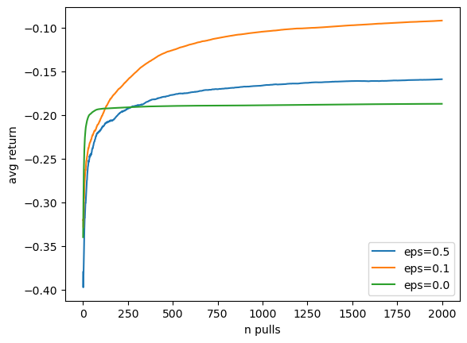

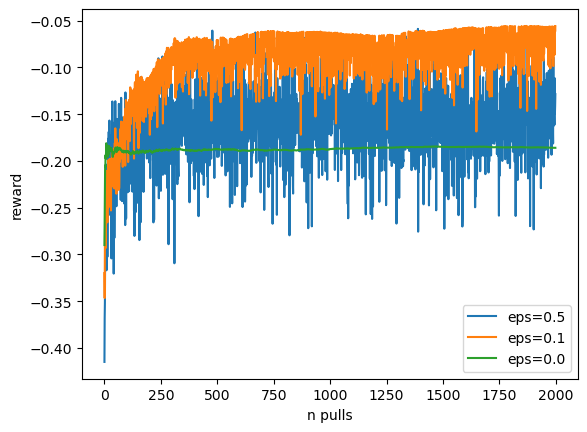

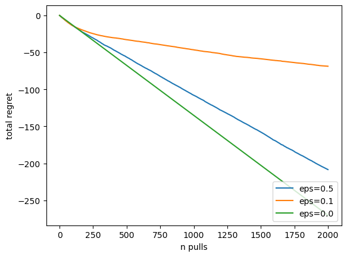

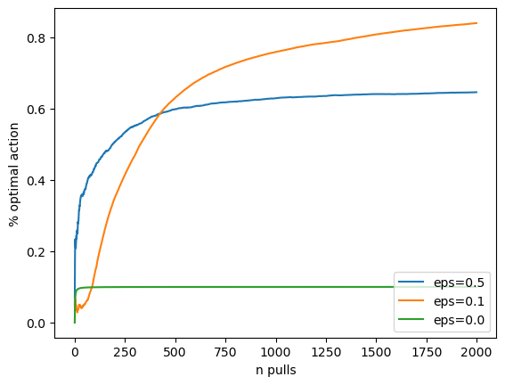

```python
plt.figure(0)
plt.xlabel("n pulls")
plt.ylabel("avg return")
plt.figure(1)
plt.xlabel("n pulls")
plt.ylabel("reward")
plt.figure(2)
plt.xlabel("n pulls")
plt.ylabel("total regret")
plt.figure(3)
plt.xlabel("n pulls")
plt.ylabel("% optimal action")

N = 20
tot_reg_rec_best = 1e8

for eps in [0.5, 0.1, .0]:
  rew_rec = np.zeros(bandit.n_pulls)
  avg_ret_rec = np.zeros(bandit.n_pulls)
  tot_reg_rec = np.zeros(bandit.n_pulls)
  opt_act_rec = np.zeros(bandit.n_pulls)
  start_time = time.time()
  for n in range(N):
    bandit.init_bandit()
    rew_rec_n, avg_ret_rec_n, tot_reg_rec_n, opt_act_rec_n = eps_greedy(bandit, eps)
    rew_rec += np.array(rew_rec_n)
    avg_ret_rec += np.array(avg_ret_rec_n)
    tot_reg_rec += np.array(tot_reg_rec_n)
    opt_act_rec += np.array(opt_act_rec_n)

  end_time = time.time()
  # print(f"time per run: {end_time - start_time}/N")
  # take the mean
  rew_rec /= N
  avg_ret_rec /= N
  tot_reg_rec /= N
  opt_act_rec /= N

  plt.figure(0)
  plt.plot(avg_ret_rec, label="eps={}".format(eps))
  plt.legend(loc="lower right")

  plt.figure(1)
  plt.plot(rew_rec[1:], label="eps={}".format(eps))
  plt.legend(loc="lower right")

  plt.figure(2)
  plt.plot(tot_reg_rec, label="eps={}".format(eps))
  plt.legend(loc="lower right")

  plt.figure(3)
  plt.plot(opt_act_rec, label="eps={}".format(eps))
  plt.legend(loc="lower right")


  if tot_reg_rec[-1] < tot_reg_rec_best:
        ep_greedy_dict = {
        'opt_act':opt_act_rec,
        'regret_list':tot_reg_rec,}
        tot_reg_rec_best = tot_reg_rec[-1]
```

#### Analysis:

Explain the results from the perspective of exploration and how different $\epsilon$ values affect the results.

#### Q1.b4: Optimistic Initial Values

We want to run the optimistic initial value method on the same problem described above for the initial q values of -1 and +1 for all arms. Compare its performance, measured by the average reward across $N$=20 runs as a function of the number of pulls, with the non-optimistic setting with initial q values of 0 for all arms. For both optimistic and non-optimistic settings, $\epsilon$=0.

```python
plt.figure(4)
plt.xlabel("n pulls")
plt.ylabel("avg return")

plt.figure(5)
plt.xlabel("n pulls")
plt.ylabel("reward")

plt.figure(6)
plt.xlabel("n pulls")
plt.ylabel("total regret")

N = 20
for init_q in [-1, 1]:
  rew_rec = np.zeros(bandit.n_pulls)
  avg_ret_rec = np.zeros(bandit.n_pulls)
  for n in range(N):
    bandit.init_bandit()
    rew_rec_n, avg_ret_rec_n, tot_reg_rec_n, opt_act_rec_n = eps_greedy(bandit, eps=0.0, init_q=init_q)

    rew_rec += np.array(rew_rec_n)
    avg_ret_rec += np.array(avg_ret_rec_n)
    tot_reg_rec += np.array(tot_reg_rec_n)

  avg_ret_rec /= N
  rew_rec /= N
  tot_reg_rec /= N
  plt.figure(4)
  plt.plot(avg_ret_rec[1:], label="q_init_val={}".format(init_q))
  plt.legend(loc="lower right")

  plt.figure(5)
  plt.plot(rew_rec[1:], label="q_init_val={}".format(init_q))
  plt.legend(loc="lower right")

  plt.figure(6)
  plt.plot(tot_reg_rec[1:], label="q_init_val={}".format(init_q))
  plt.legend(loc="lower right")
```

```python
### Solution

def optimism(bandit, eps, init_q):
    """
    Perform epsilon-greedy strategy with optional optimistic initial values.
    .inputs:
      bandit: Bandit object
      eps: Epsilon value for exploration
      init_q: Initial value for estimated rewards (optimistic or non-optimistic)
    .outputs:
      rew_rec: list of rewards at each step
      avg_ret_rec: list of average returns at each step
      tot_reg_rec: list of cumulative regrets at each step
      opt_act_rec: list of percentage optimal actions at each step
    """
    rew_rec = []
    avg_ret_rec = []
    tot_reg_rec = []
    opt_act_rec = []

    n_pulls = bandit.n_pulls
    actual_toxicity_prob = np.array(bandit.actual_toxicity_prob)
    opt_arm = np.argmin(np.abs(actual_toxicity_prob - bandit.theta))

    cumulative_reward = 0
    optimal_action_count = 0
    cumulative_regret = 0

    # Initialize estimated probabilities with optimistic or non-optimistic values
    estimated_probs = np.full(bandit.n_arm, init_q)

    for t in range(n_pulls):
        # Exploration vs Exploitation
        if np.random.rand() < eps:  # Exploration
            arm = np.random.randint(0, bandit.n_arm)
        else:  # Exploitation
            arm = np.argmin(np.abs(estimated_probs - bandit.theta))

        # Pull the arm and get the reward
        reward = bandit.pull(arm)

        # Update cumulative reward and regret
        cumulative_reward += reward
        if arm == opt_arm:
            optimal_action_count += 1

        regret = abs(bandit.theta - actual_toxicity_prob[opt_arm]) - abs(bandit.theta - actual_toxicity_prob[arm])
        cumulative_regret += regret

        # Update estimated probabilities using running average
        if bandit.num_dose_selected[arm] > 0:
            estimated_probs[arm] = bandit.num_toxic[arm] / bandit.num_dose_selected[arm]

        # Record metrics
        rew_rec.append(reward)
        avg_ret_rec.append(cumulative_reward / (t + 1))
        tot_reg_rec.append(cumulative_regret)
        opt_act_rec.append(optimal_action_count / (t + 1))

    return rew_rec, avg_ret_rec, tot_reg_rec, opt_act_rec
```

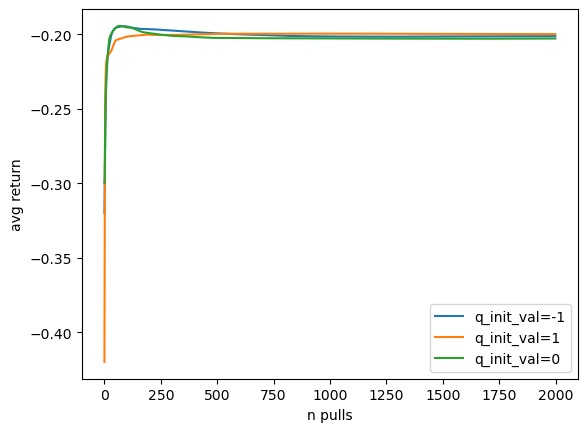

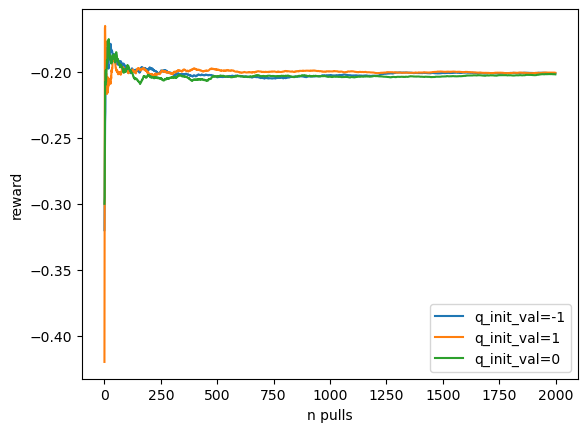

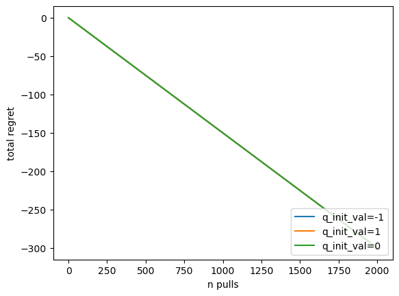

```python
plt.figure(4)
plt.xlabel("n pulls")
plt.ylabel("avg return")

plt.figure(5)
plt.xlabel("n pulls")
plt.ylabel("reward")

plt.figure(6)
plt.xlabel("n pulls")
plt.ylabel("total regret")

N = 20
for init_q in [-1, 1, 0]:  # Testing optimistic (+1), pessimistic (-1), and non-optimistic (0)
    rew_rec = np.zeros(bandit.n_pulls)
    avg_ret_rec = np.zeros(bandit.n_pulls)
    tot_reg_rec = np.zeros(bandit.n_pulls)

    for n in range(N):
        bandit.init_bandit()
        rew_rec_n, avg_ret_rec_n, tot_reg_rec_n, opt_act_rec_n = optimism(bandit, eps=0.0, init_q=init_q)

        rew_rec += np.array(rew_rec_n)
        avg_ret_rec += np.array(avg_ret_rec_n)
        tot_reg_rec += np.array(tot_reg_rec_n)

    avg_ret_rec /= N
    rew_rec /= N
    tot_reg_rec /= N

    # Plot average return
    plt.figure(4)
    plt.plot(avg_ret_rec, label="q_init_val={}".format(init_q))
    plt.legend(loc="lower right")

    # Plot rewards
    plt.figure(5)
    plt.plot(rew_rec, label="q_init_val={}".format(init_q))
    plt.legend(loc="lower right")

    # Plot total regret
    plt.figure(6)
    plt.plot(tot_reg_rec, label="q_init_val={}".format(init_q))
    plt.legend(loc="lower right")

plt.show()
```

#### Analysis

Explain how initial q values affect the exploration and the performance.

# Upper confidence bound arm selection

### Q1.c: Upper-Confidence-Bound action selection (15 points)

#### Q1.c1: UCB algorithm implementation (5 points)

Implement the UCB algorithm on the same MAB problem as above.

```python
def ucb(
    bandit: Bandit,
    c: float,
    init_q: float = .0
    ) -> Tuple[list, list, list]:
  """
  .inputs:
    bandit: A bandit problem, instantiated from the above class.
    c: The additional term coefficient.
    init_q: Initial estimation of each arm's value.
  .outputs:
    rew_record: The record of rewards at each timestep.
    avg_ret_record: The average summation of rewards up to step t, where t goes from 0 to n_pulls. For example: If
    we define `ret_T` = \sum^T_{t=0}{r_t}, `avg_ret_record` = ret_T / (1+T).
    tot_reg_record: The  regret up to step t, where t goes from 0 to n_pulls.
    opt_action_perc_record: Percentage of optimal arm selected.
  """
  # init q values (the estimates)
  q = np.array([init_q]*bandit.n_arm, dtype=float)

  ret = .0
  rew_record = []
  avg_ret_record = []
  tot_reg_record = []
  opt_action_perc_record = []

  for t in range(bandit.n_pulls):
    # Assuming to take the first arm always when there is no exploration
    # ----------------------------------------------
    ...
    # ----------------------------------------------


  return rew_record, avg_ret_record, tot_reg_record, opt_action_perc_record
```

```python
### Solution

def ucb(
    bandit: Bandit,
    c: float,
    init_q: float = 0.0
) -> Tuple[list, list, list, list]:
    """
    .inputs:
      bandit: A bandit problem, instantiated from the above class.
      c: The exploration coefficient.
      init_q: Initial estimation of each arm's value.
    .outputs:
      rew_record: The record of rewards at each timestep.
      avg_ret_record: The average summation of rewards up to step t, where t goes from 0 to n_pulls.
      tot_reg_record: The regret up to step t, where t goes from 0 to n_pulls.
      opt_action_perc_record: Percentage of optimal arm selected.
    """
    # Initialize Q values, counts, and metrics
    q = np.array([init_q] * bandit.n_arm, dtype=float)  # Estimated values of each arm
    n_a = np.zeros(bandit.n_arm)  # Number of times each arm has been pulled
    ret = 0.0  # Cumulative reward
    rew_record = []  # Reward at each time step
    avg_ret_record = []  # Average return at each time step
    tot_reg_record = []  # Cumulative regret at each time step
    opt_action_perc_record = []  # Percentage of optimal actions

    # Determine the optimal arm
    actual_toxicity_prob = np.array(bandit.actual_toxicity_prob)
    opt_arm = np.argmin(np.abs(actual_toxicity_prob - bandit.theta))

    optimal_action_count = 0  # Counter for the number of times the optimal arm is selected
    cumulative_regret = 0.0  # Cumulative regret

    for t in range(bandit.n_pulls):
        # Select the arm using the UCB formula
        if t < bandit.n_arm:
            # Initially pull each arm once to ensure they all have counts > 0
            arm = t
        else:
            # Compute UCB values
            ucb_values = q + c * np.sqrt(np.log(t + 1) / (n_a + 1e-5))
            arm = np.argmax(ucb_values)

        # Pull the selected arm and observe the reward
        reward = bandit.pull(arm)

        # Update the counts and Q values for the selected arm
        n_a[arm] += 1
        q[arm] += (reward - q[arm]) / n_a[arm]

        # Update cumulative reward and regret
        ret += reward
        regret = abs(bandit.theta - actual_toxicity_prob[opt_arm]) - abs(bandit.theta - actual_toxicity_prob[arm])
        cumulative_regret += regret

        # Track optimal arm selection
        if arm == opt_arm:
            optimal_action_count += 1

        # Record metrics
        rew_record.append(reward)
        avg_ret_record.append(ret / (t + 1))
        tot_reg_record.append(cumulative_regret)
        opt_action_perc_record.append(optimal_action_count / (t + 1))

    return rew_record, avg_ret_record, tot_reg_record, opt_action_perc_record


rew_rec, avg_ret_rec, tot_reg_rec, opt_act_rec = ucb(bandit, c=2.0, init_q=0.0)
```

#### Q1.c2: Plotting the results

Use the driver code provided to plot: (1) The average return, (2) The reward, (3) the total regret, and (4) the percentage of optimal action across the $N$=20 runs as a function of the number of pulls (2000 pulls for each run) for three values of $c$=0, 0.5, and 2.0.

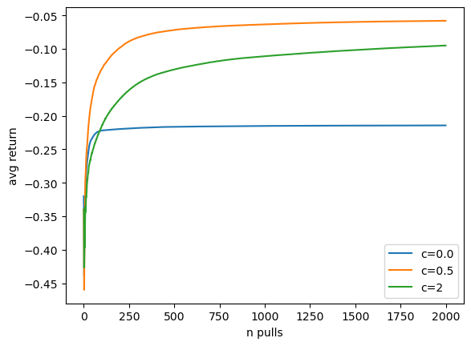

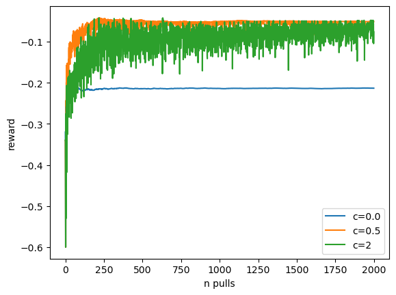

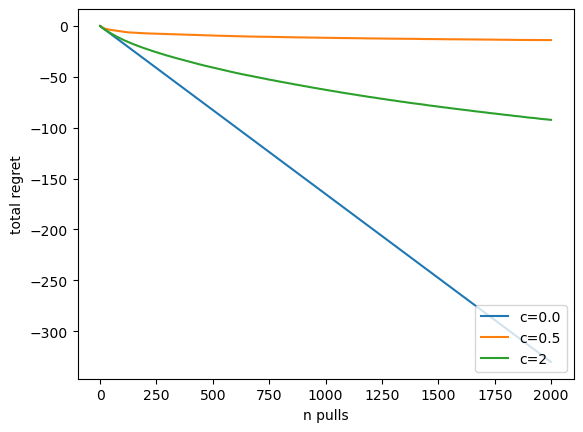

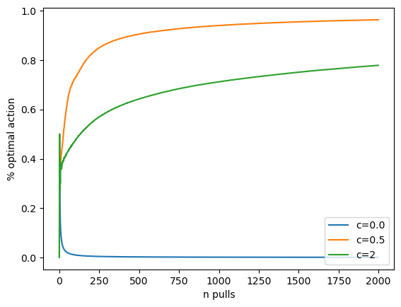

```python
plt.figure(7)
plt.xlabel("n pulls")
plt.ylabel("avg return")
plt.figure(8)
plt.xlabel("n pulls")
plt.ylabel("reward")
plt.figure(9)
plt.xlabel("n pulls")
plt.ylabel("total regret")
plt.figure(10)
plt.xlabel("n pulls")
plt.ylabel("% optimal action")

N = 20
tot_reg_rec_best = 1e8
for c in [.0, 0.5, 2]:
  rew_rec = np.zeros(bandit.n_pulls)
  avg_ret_rec = np.zeros(bandit.n_pulls)
  tot_reg_rec = np.zeros(bandit.n_pulls)
  opt_act_rec = np.zeros(bandit.n_pulls)

  for n in range(N):
    bandit.init_bandit()
    rew_rec_n, avg_ret_rec_n, tot_reg_rec_n, opt_act_rec_n = ucb(bandit, c)
    rew_rec += np.array(rew_rec_n)
    avg_ret_rec += np.array(avg_ret_rec_n)
    tot_reg_rec += np.array(tot_reg_rec_n)
    opt_act_rec += np.array(opt_act_rec_n)

  # take the mean
  rew_rec /= N
  avg_ret_rec /= N
  tot_reg_rec /= N
  opt_act_rec /= N

  plt.figure(7)
  plt.plot(avg_ret_rec, label="c={}".format(c))
  plt.legend(loc="lower right")

  plt.figure(8)
  plt.plot(rew_rec, label="c={}".format(c))
  plt.legend(loc="lower right")

  plt.figure(9)
  plt.plot(tot_reg_rec, label="c={}".format(c))
  plt.legend(loc="lower right")

  plt.figure(10)
  plt.plot(opt_act_rec, label="c={}".format(c))
  plt.legend(loc="lower right")

  if tot_reg_rec[-1] < tot_reg_rec_best:
        ucb_dict = {
        'opt_act':opt_act_rec,
        'regret_list':tot_reg_rec,}
        tot_reg_rec_best = tot_reg_rec[-1]
```

#### Q1.c3: Analysis

Explain the results from the perspective of exploration and how different $c$ values affect the results.